# Содержание

### Выводы

Можно сделать следующие рекомендации для отдела маркетинга:  
1) Сократить вложения в неэффективные рекламные кампании TipTop и FaceBoom и обратить внимание на каналы, например, MediaTornado или lambdaMediaArts.  
2) Более тщательно изучить рынок и пользователей США, как ключевого рынка, и не делать ставку только на рекламу через TipTop и FaceBoom - можно попробовать обратить внимание на эффективно показавшие себя в других странах рекламные каналы.  
3) Обратить внимание на платформу PC, там не очень высокая конверсия, зато эти клиенты стабильно окупаются, и это самая популярная платформа для нашего приложения за пределами США.

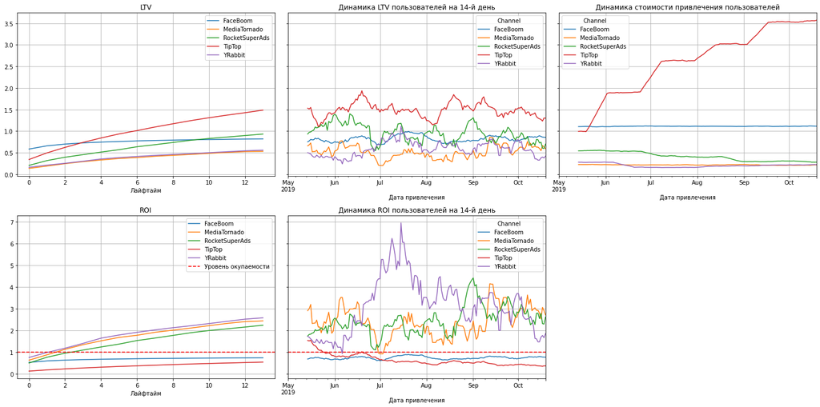

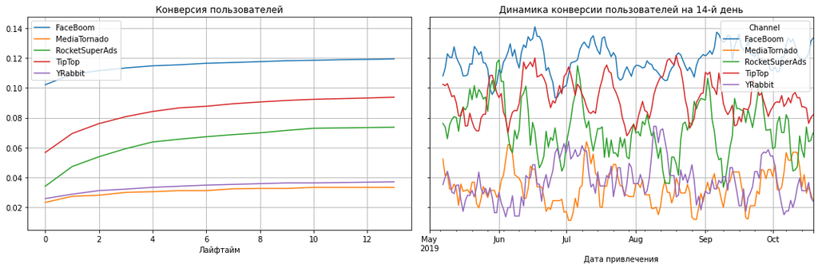

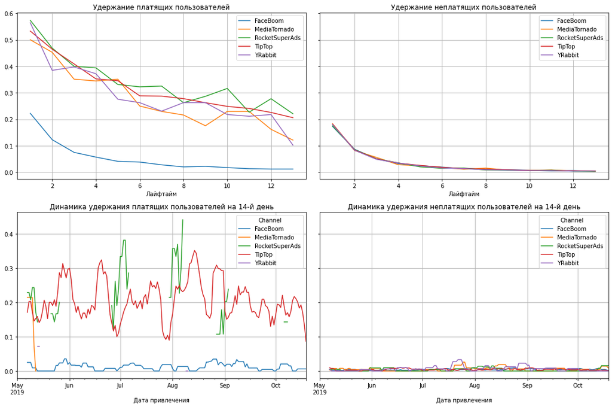

```python
# Ячейка ревьюера:
dimensions = ['Channel']

ltv_raw, ltv_grouped, ltv_history, roi_grouped, roi_history = get_ltv(
    profiles.query('Region == "United States"'), purchases, observation_date, 14, dimensions=dimensions)
conversion_raw, conversion_grouped, conversion_history = get_conversion(
    profiles.query('Region == "United States"'), purchases, observation_date, 14, dimensions=dimensions)
retention_raw, retention_grouped, retention_history = get_retention(
    profiles.query('Region == "United States"'), visits, observation_date, 14, dimensions=dimensions)

plot_ltv_roi(ltv_grouped, ltv_history, roi_grouped, roi_history, 14, window=14)
plot_conversion(conversion_grouped, conversion_history, 14)
plot_retention(retention_grouped, retention_history, 14)
```